# Week 4

Evan Wu

#### Code Background

Looking at whiff data for right-handed pitchers (from 2022, 85 pitchers with 1842+ seasonal pitches).

#### Libraries

```r
library(tidyverse)
library(knitr)
library(glmnet)
library(patchwork)
library(olsrr)
```

```r
# Geom Zone (Jackie's) ####

geom_zone <- function(top = 11/3, bottom = 3/2, linecolor = "black"){
  geom_rect(xmin = -.7083, xmax = .7083, ymin = bottom, ymax = top,
            alpha = 0, color = linecolor, linewidth = 0.75)
}

# c(0, 0, -.25, -.5, -.25))

geom_plate <- function(pov = "pitcher"){
   df <- case_when(
     pov == "pitcher" ~
       data.frame(x = c(-.7083, .7083, .7083 ,0, -.7083), y = c(0, 0, .25, .5, .25)),
     pov == "catcher" ~
       data.frame(x = c(-.7083, .7083, .7083 ,0, -.7083), y = c(0, 0, -.25, -.5, -.25))
   )

   g <- geom_polygon(data = df, aes(x = x, y = y), fill = "white", color = "black", linewidth = 1.25)
  g
}
```

#### Data

Added code to calculate whether a batted ball is a barrel or not. Used code to find the slopes and intercepts for both lines and then inputted rounded coefficients into the model for more simplicity.

Added predicted whiff rate. There were a few hitters with more than 300 pitches of a given pitch type, so for those I used their true whiff percentage.

Also added a strike metric that includes all pitches that can strike a hitter out: called and swinging strikes, as well as foul tips and foul bunts.

```r
rhp <- read_csv("CSVs/rhp_pitches.csv") %>%
  select(-...1) %>%
  filter(!is.na(pfx_z)) %>%
  mutate(distance_sweet = sqrt(((plate_x - 0.85)^2)+((plate_z - 1.55)^2))) %>%
  mutate(zone = case_when(distance < 2 ~ zone,
                          distance >= 2 & plate_z > (sz_top + sz_bot)/2 ~ 16,
                          distance >= 2 & plate_z <= (sz_top + sz_bot)/2 ~ 17)) %>%
  mutate(ab_id = paste0(game_date, "_", player_id, "_", at_bat_number),
         prev_ab_id = lead(ab_id, 1)) %>%
  mutate(prev_pitch = ifelse(ab_id == prev_ab_id, lead(pitch_type, 1), NA)) %>%
  select(-ab_id, -prev_ab_id) %>%
  mutate(prev_pitch = case_when(prev_pitch  %in% c("FF", "FC", "SI") ~ "Fastball",
                                prev_pitch %in% c("SL", "CU", "KC",
                                                  "SV", "ST", "CS") ~ "Breaking Ball",
                                prev_pitch  %in% c("CH", "FS") ~ "Off Speed")) %>%
  mutate(zone = relevel(as.factor(zone), ref = 5))

# New Code for Barrels

# Upper Limit
m <- (50 - 30) / (116 - 98)
b <- 30 - m * 98
paste0("y = ", round(m, 2), "x ", round(b, 2))
```

```
## [1] "y = 1.11x -78.89"
```

```r
# Lower Limit
m <- (8 - 26) / (116 - 98)
b <- 26 - m * 98
paste0("y = ", round(m, 2), "x + ", round(b, 2))
```

```
## [1] "y = -1x + 124"
```

```r
# Making Limits
rhp <- rhp %>%
  mutate(barrel_upper_lim = case_when(
    launch_speed <= 98 ~ 30,
    launch_speed > 98 & launch_speed < 116 ~ (1.11)*launch_speed - 78.89,
    launch_speed >= 116 ~ 50),
        barrel_lower_lim = case_when(
    launch_speed <= 98 ~ 26,
    launch_speed > 98 & launch_speed < 116 ~ (-1)*launch_speed + 124,
    launch_speed >= 116 ~ 8)
    )

# Barrel
rhp <- rhp %>%
  mutate(Barrel = launch_angle <= barrel_upper_lim &
                  launch_angle >= barrel_lower_lim &
                  launch_speed >= 98)

# Strike
rhp <- rhp %>%
  mutate(STRIKE = ifelse(description  %in% c("called_strike", "swinging_strike",
                                           "foul_tip", "bunt_foul_tip", "foul_bunt",
                                           "swinging_strike_blocked", "missed_bunt"),
                       1, 0))


# Batter Whiff
batter_stats <- rhp %>%
  group_by(batter,
           pitch_type) %>%
  summarize(rate = mean(whiff),
                      pitches = n()) %>%
  mutate(pred_bwhiff = (pitches / 300)*rate + ((300-pitches)/300)*0.1561567) %>%
  mutate(pred_bwhiff = ifelse(pitches >= 300, rate, pred_bwhiff))

# Merging Whiff Prediction with RHP
rhp <- rhp %>%
  left_join(select(batter_stats, -rate, -pitches),
             by = c("batter" = "batter", "pitch_type" = "pitch_type"))

rhp <- rhp %>%
  mutate(prev_pitch = ifelse(is.na(prev_pitch), "None", prev_pitch)) %>%
  mutate(Count = paste0(balls, "-", strikes)) %>%
  mutate(Count = as.factor(Count))

sliders <- rhp %>%
  filter(hitter == "R") %>%
  filter(pitch_type == "SL") %>%
  mutate(count = paste0(balls, "_", strikes),
         prev_pitch = as.factor(prev_pitch)) %>%
  mutate(prev_pitch_ff = ifelse(prev_pitch == "FF", 1, 0))

fastballs <- rhp %>%
  filter(hitter == "R") %>%
  filter(pitch_type == fb_type) %>%
  mutate(count = paste0(balls, "_", strikes),
         prev_pitch = as.factor(prev_pitch))
```

#### BARREL Slider Initial Model

```r
# Initial Model
sl_model_barrel_all <- glm(Barrel ~ pitch_speed + pfx_x + pfx_z + plate_x + plate_z + zone +
              count + pfx_total + speed_change + break_change + distance + prev_pitch +
                speed_fb_diff + pfx_x_fb_diff + pfx_z_fb_diff + release_spin_rate +
                I(plate_x^2) + I(plate_z^2) + pred_bwhiff,
              data = sliders, family = binomial)

# Model Evaluation
summary(sl_model_barrel_all)
```

```
##
## Call:
## glm(formula = Barrel ~ pitch_speed + pfx_x + pfx_z + plate_x +
##     plate_z + zone + count + pfx_total + speed_change + break_change +
##     distance + prev_pitch + speed_fb_diff + pfx_x_fb_diff + pfx_z_fb_diff +
##     release_spin_rate + I(plate_x^2) + I(plate_z^2) + pred_bwhiff,
##     family = binomial, data = sliders)
##
## Coefficients: (1 not defined because of singularities)
##                       Estimate Std. Error z value Pr(>|z|)
## (Intercept)         -4.321e+00  3.744e+00  -1.154  0.24846
## pitch_speed         -6.795e-02  3.289e-02  -2.066  0.03882 *
## pfx_x               -5.891e-01  4.503e-01  -1.308  0.19078
## pfx_z               -3.315e-01  3.029e-01  -1.095  0.27368
## plate_x             -6.271e-01  3.077e-01  -2.038  0.04155 *
## plate_z              7.179e+00  2.089e+00   3.436  0.00059 ***
## zone1               -1.502e+01  8.390e+02  -0.018  0.98572
## zone2                4.203e-02  5.539e-01   0.076  0.93951
## zone3                4.327e-01  7.678e-01   0.564  0.57307
## zone4                7.583e-02  2.999e-01   0.253  0.80041
## zone6                2.390e-01  2.600e-01   0.919  0.35814
## zone7                6.403e-01  3.699e-01   1.731  0.08341 .
## zone8               -1.419e-01  2.949e-01  -0.481  0.63035
## zone9               -1.065e-01  3.427e-01  -0.311  0.75597
## zone11              -1.455e+01  1.124e+03  -0.013  0.98967
## zone12              -1.301e+01  5.346e+02  -0.024  0.98058
## zone13              -1.149e+00  1.100e+00  -1.044  0.29645
## zone14              -1.079e+00  7.369e-01  -1.464  0.14327
## zone16               7.530e-02  3.710e-01   0.203  0.83914
## zone17              -1.124e+01  8.648e+02  -0.013  0.98963
## count0_1            -4.061e-01  2.500e-01  -1.624  0.10430
## count0_2            -5.602e-02  2.981e-01  -0.188  0.85094
## count1_0             8.469e-02  2.577e-01   0.329  0.74241
## count1_1            -3.671e-01  2.686e-01  -1.367  0.17166
## count1_2            -1.924e-01  2.600e-01  -0.740  0.45949
## count2_0            -6.471e-01  6.163e-01  -1.050  0.29370
## count2_1             4.682e-01  2.805e-01   1.669  0.09507 .
## count2_2            -1.077e-01  2.659e-01  -0.405  0.68548
## count3_0            -1.486e+01  2.190e+03  -0.007  0.99459
## count3_1             2.713e-01  5.059e-01   0.536  0.59176
```

[output cut: 11 more lines]

```
## release_spin_rate    1.135e-04  3.362e-04   0.338  0.73566
## I(plate_x^2)        -7.019e-01  6.137e-01  -1.144  0.25270
## I(plate_z^2)        -9.291e-01  3.753e-01  -2.475  0.01331 *
## pred_bwhiff          6.622e-01  3.256e+00   0.203  0.83883
## ---
## Signif. codes:  0 '***' 0.001 '**' 0.01 '*' 0.05 '.' 0.1 ' ' 1
##
## (Dispersion parameter for binomial family taken to be 1)
##
##     Null deviance: 2208.5  on 6653  degrees of freedom
## Residual deviance: 1991.3  on 6610  degrees of freedom
##   (15452 observations deleted due to missingness)
## AIC: 2079.3
##
## Number of Fisher Scoring iterations: 16
```

#### BARREL Slider Refined Model & Predictions

Variables Removed: zone, count, prev_pitch, pfx_x_fb_diff, release_spin_rate, pred_bwhiff, pfx_z_fb_diff, pfx_total, pfx_x, pfx_z, speed_change, break_change, speed_fb_diff, plate_x^2

```r
# Refined Model
sl_model_barrel <- glm(Barrel ~ pitch_speed + plate_x + plate_z +
              distance + I(plate_z^2),
              data = sliders, family = binomial)

# Model Evaluation
summary(sl_model_barrel)
```

```
##
## Call:
## glm(formula = Barrel ~ pitch_speed + plate_x + plate_z + distance +
##     I(plate_z^2), family = binomial, data = sliders)
##
## Coefficients:
##              Estimate Std. Error z value Pr(>|z|)
## (Intercept)   -9.4702     2.3519  -4.027 5.66e-05 ***
## pitch_speed   -0.0442     0.0212  -2.084   0.0371 *
## plate_x       -0.7595     0.1662  -4.570 4.88e-06 ***
## plate_z       10.0827     1.4162   7.119 1.08e-12 ***
## distance      -4.3218     0.7302  -5.918 3.25e-09 ***
## I(plate_z^2)  -1.1946     0.2628  -4.546 5.48e-06 ***
## ---
## Signif. codes:  0 '***' 0.001 '**' 0.01 '*' 0.05 '.' 0.1 ' ' 1
##
## (Dispersion parameter for binomial family taken to be 1)
##
##     Null deviance: 2209.4  on 6664  degrees of freedom
## Residual deviance: 2041.2  on 6659  degrees of freedom
##   (15441 observations deleted due to missingness)
## AIC: 2053.2
##
## Number of Fisher Scoring iterations: 7
```

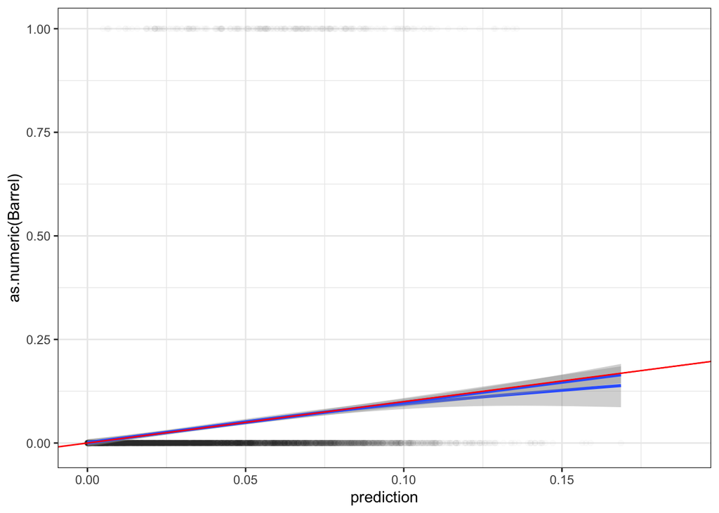

```r
# Model Predictions
sl_preds_barrel <- sliders %>%
  mutate(prediction_log = predict(sl_model_barrel, sliders),
         prediction = 1 / (1 + exp(-prediction_log)),
         rounded_pred = case_when(
           prediction >= 0.5 ~ 1,
           prediction < 0.5 ~ 0
         )) %>%
  filter(!is.na(prediction))

ggplot(sl_preds_barrel, aes(x = prediction, y = as.numeric(Barrel))) +
  geom_point(alpha = 0.01) +
  geom_smooth() +
  geom_smooth(method = "lm") +
  geom_abline(slope = 1, intercept = 0, color = "red") +
  theme_bw()
```

#### BARREL Fastball Initial Model

```r
# Initial Model
fb_model_barrel_all <- glm(Barrel ~ pitch_speed + pfx_x + pfx_z + plate_x + plate_z + zone +
              count + pfx_total + speed_change + break_change + distance + prev_pitch +
                release_spin_rate +
                I(plate_x^2) + I(plate_z^2) + pred_bwhiff,
              data = fastballs, family = binomial)

# Model Evaluation
summary(fb_model_barrel_all)
```

```
##
## Call:
## glm(formula = Barrel ~ pitch_speed + pfx_x + pfx_z + plate_x +
##     plate_z + zone + count + pfx_total + speed_change + break_change +
##     distance + prev_pitch + release_spin_rate + I(plate_x^2) +
##     I(plate_z^2) + pred_bwhiff, family = binomial, data = fastballs)
##
## Coefficients:
##                       Estimate Std. Error z value Pr(>|z|)
## (Intercept)          1.220e+01  3.956e+03   0.003 0.997539
## pitch_speed         -5.244e-02  1.760e-02  -2.979 0.002890 **
## pfx_x                6.237e-02  2.119e-01   0.294 0.768537
## pfx_z                7.371e-01  3.135e-01   2.351 0.018722 *
## plate_x              2.611e-01  1.279e-01   2.041 0.041246 *
## plate_z              5.260e+00  1.055e+00   4.986 6.16e-07 ***
## zone1                2.642e-01  4.408e-01   0.599 0.548961
## zone2               -1.051e-01  2.801e-01  -0.375 0.707621
## zone3               -3.249e-01  5.285e-01  -0.615 0.538770
## zone4                2.687e-01  1.561e-01   1.721 0.085202 .
## zone6               -2.894e-02  1.564e-01  -0.185 0.853220
## zone7                5.576e-01  2.443e-01   2.282 0.022476 *
## zone8               -2.250e-01  2.189e-01  -1.028 0.304095
## zone9               -3.326e-01  2.746e-01  -1.211 0.225852
## zone11               7.797e-01  5.060e-01   1.541 0.123319
## zone12              -9.786e-01  1.033e+00  -0.948 0.343285
## zone13               8.051e-01  3.395e-01   2.372 0.017702 *
## zone14              -1.376e+01  1.894e+02  -0.073 0.942068
## zone16              -2.226e-01  1.676e-01  -1.328 0.184084
## zone17              -1.292e+01  6.803e+02  -0.019 0.984844
## count0_1            -1.537e+01  3.956e+03  -0.004 0.996900
## count0_2            -1.557e+01  3.956e+03  -0.004 0.996859
## count1_0            -1.524e+01  3.956e+03  -0.004 0.996927
## count1_1            -1.524e+01  3.956e+03  -0.004 0.996927
## count1_2            -1.537e+01  3.956e+03  -0.004 0.996901
## count2_0            -1.496e+01  3.956e+03  -0.004 0.996983
## count2_1            -1.507e+01  3.956e+03  -0.004 0.996961
## count2_2            -1.509e+01  3.956e+03  -0.004 0.996956
## count3_0            -1.419e+01  3.956e+03  -0.004 0.997137
## count3_1            -1.494e+01  3.956e+03  -0.004 0.996988
## count3_2            -1.517e+01  3.956e+03  -0.004 0.996941
## pfx_total           -1.085e-01  4.564e-01  -0.238 0.812013
## speed_change        -7.848e-02  4.632e-02  -1.694 0.090217 .
## break_change        -6.776e-01  3.797e-01  -1.784 0.074344 .
## distance            -2.981e+00  8.137e-01  -3.664 0.000248 ***
## prev_pitchFastball   5.518e-02  9.515e-02   0.580 0.561966
## prev_pitchNone      -1.514e+01  3.956e+03  -0.004 0.996946
## prev_pitchOff Speed -8.457e-02  1.823e-01  -0.464 0.642751
## release_spin_rate   -6.242e-04  2.477e-04  -2.520 0.011739 *
## I(plate_x^2)        -2.658e-01  2.758e-01  -0.964 0.335205
## I(plate_z^2)        -4.347e-01  1.504e-01  -2.890 0.003846 **
## pred_bwhiff          2.520e+00  1.443e+00   1.746 0.080790 .
## ---
## Signif. codes:  0 '***' 0.001 '**' 0.01 '*' 0.05 '.' 0.1 ' ' 1
##
## (Dispersion parameter for binomial family taken to be 1)
##
##     Null deviance: 5861.4  on 15618  degrees of freedom
## Residual deviance: 5604.0  on 15577  degrees of freedom
##   (27158 observations deleted due to missingness)
## AIC: 5688
##
## Number of Fisher Scoring iterations: 16
```

#### BARREL Fastball Refined Model & Predictions

Variables Removed: count, zone, prev_pitch, pfx_total, plate_x, pfx_x, plate_x^2, pred_bwhiff

```r
# Refined Model
fb_model_barrel <- glm(Barrel ~ pitch_speed + pfx_z + plate_z +
              speed_change + break_change + distance +
                release_spin_rate + I(plate_z^2),
              data = fastballs, family = binomial)

# Model Evaluation
summary(fb_model_barrel)
```

```
##
## Call:
## glm(formula = Barrel ~ pitch_speed + pfx_z + plate_z + speed_change +
##     break_change + distance + release_spin_rate + I(plate_z^2),
##     family = binomial, data = fastballs)
##
## Coefficients:
##                     Estimate Std. Error z value Pr(>|z|)
## (Intercept)       -3.6498544  1.8210621  -2.004 0.045044 *
## pitch_speed       -0.0576160  0.0170294  -3.383 0.000716 ***
## pfx_z              0.7136453  0.1141051   6.254 3.99e-10 ***
## plate_z            6.5742711  0.7788326   8.441  < 2e-16 ***
## speed_change      -0.0957241  0.0433135  -2.210 0.027103 *
## break_change      -0.8256603  0.3344808  -2.468 0.013569 *
## distance          -3.6889609  0.4309917  -8.559  < 2e-16 ***
## release_spin_rate -0.0005700  0.0002327  -2.449 0.014320 *
## I(plate_z^2)      -0.5910700  0.1220873  -4.841 1.29e-06 ***
## ---
## Signif. codes:  0 '***' 0.001 '**' 0.01 '*' 0.05 '.' 0.1 ' ' 1
##
## (Dispersion parameter for binomial family taken to be 1)
##
##     Null deviance: 5861.4  on 15618  degrees of freedom
## Residual deviance: 5672.3  on 15610  degrees of freedom
##   (27158 observations deleted due to missingness)
## AIC: 5690.3
##
## Number of Fisher Scoring iterations: 6
```

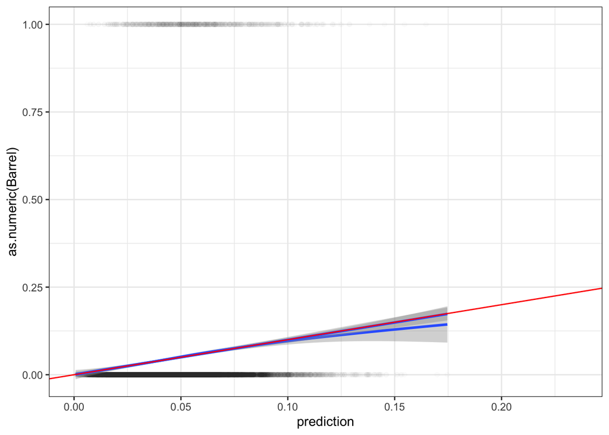

```r
# Model Predictions
fb_preds_barrel <- fastballs %>%
  mutate(prediction_log = predict(fb_model_barrel, fastballs),
         prediction = 1 / (1 + exp(-prediction_log)),
         rounded_pred = case_when(
           prediction >= 0.5 ~ 1,
           prediction < 0.5 ~ 0
         )) %>%
  filter(!is.na(prediction))

ggplot(fb_preds_barrel, aes(x = prediction, y = as.numeric(Barrel))) +
  geom_point(alpha = 0.01) +
  geom_smooth() +
  geom_smooth(method = "lm") +
  geom_abline(slope = 1, intercept = 0, color = "red") +
  theme_bw()
```

#### STRIKE Slider Initial Model

```r
# Initial Model
sl_model_strike_all <- glm(STRIKE ~ pitch_speed + pfx_x + pfx_z + plate_x + plate_z + zone +
              count + pfx_total + speed_change + break_change + distance + prev_pitch +
                speed_fb_diff + pfx_x_fb_diff + pfx_z_fb_diff + release_spin_rate +
                I(plate_x^2) + I(plate_z^2) + pred_bwhiff,
              data = sliders, family = binomial)

# Model Evaluation
summary(sl_model_strike_all)
```

```
##
## Call:
## glm(formula = STRIKE ~ pitch_speed + pfx_x + pfx_z + plate_x +
##     plate_z + zone + count + pfx_total + speed_change + break_change +
##     distance + prev_pitch + speed_fb_diff + pfx_x_fb_diff + pfx_z_fb_diff +
##     release_spin_rate + I(plate_x^2) + I(plate_z^2) + pred_bwhiff,
##     family = binomial, data = sliders)
##
## Coefficients:
##                       Estimate Std. Error z value Pr(>|z|)
## (Intercept)          4.086e+00  7.889e+01   0.052 0.958693
## pitch_speed          1.289e-02  7.931e-03   1.625 0.104171
## pfx_x                2.621e-01  1.113e-01   2.355 0.018506 *
## pfx_z                1.105e-01  7.438e-02   1.486 0.137291
## plate_x              2.763e-01  5.868e-02   4.710 2.48e-06 ***
## plate_z              1.784e+00  1.066e-01  16.733  < 2e-16 ***
## zone1                1.351e+00  2.948e-01   4.583 4.59e-06 ***
## zone2                7.193e-01  1.941e-01   3.706 0.000211 ***
## zone3                5.791e-01  2.597e-01   2.230 0.025727 *
## zone4                5.932e-01  1.109e-01   5.349 8.83e-08 ***
## zone6                2.891e-01  8.269e-02   3.497 0.000471 ***
## zone7                6.931e-01  1.312e-01   5.282 1.28e-07 ***
## zone8                3.247e-01  9.103e-02   3.567 0.000361 ***
## zone9                5.844e-01  8.479e-02   6.893 5.48e-12 ***
## zone11              -1.136e+00  7.449e-01  -1.525 0.127200
## zone12               4.537e-01  2.046e-01   2.217 0.026613 *
## zone13               3.888e-02  1.445e-01   0.269 0.787908
## zone14               5.639e-01  9.267e-02   6.085 1.17e-09 ***
## zone16               1.050e+00  9.417e-02  11.152  < 2e-16 ***
## zone17               7.570e-01  1.792e-01   4.223 2.41e-05 ***
## count0_1            -1.049e+01  7.889e+01  -0.133 0.894203
## count0_2            -1.081e+01  7.889e+01  -0.137 0.891028
## count1_0            -1.004e+01  7.889e+01  -0.127 0.898736
## count1_1            -1.039e+01  7.889e+01  -0.132 0.895246
## count1_2            -1.075e+01  7.889e+01  -0.136 0.891579
## count2_0            -9.745e+00  7.889e+01  -0.124 0.901691
## count2_1            -1.028e+01  7.889e+01  -0.130 0.896338
## count2_2            -1.078e+01  7.889e+01  -0.137 0.891309
## count3_0            -9.295e+00  7.889e+01  -0.118 0.906210
## count3_1            -1.013e+01  7.889e+01  -0.128 0.897875
```

[output cut: 11 more lines]

```
## release_spin_rate    3.713e-04  7.780e-05   4.772 1.82e-06 ***
## I(plate_x^2)        -8.791e-01  6.784e-02 -12.959  < 2e-16 ***
## I(plate_z^2)        -5.657e-01  4.603e-02 -12.291  < 2e-16 ***
## pred_bwhiff          9.164e+00  7.765e-01  11.802  < 2e-16 ***
## ---
## Signif. codes:  0 '***' 0.001 '**' 0.01 '*' 0.05 '.' 0.1 ' ' 1
##
## (Dispersion parameter for binomial family taken to be 1)
##
##     Null deviance: 27338  on 22074  degrees of freedom
## Residual deviance: 24708  on 22030  degrees of freedom
##   (31 observations deleted due to missingness)
## AIC: 24798
##
## Number of Fisher Scoring iterations: 9
```

#### STRIKE Slider Refined Model & Predictions

```r
# Refined Model

sliders <- sliders %>%
  mutate(fb_prev = ifelse(prev_pitch == "Fastball", 1, 0)) %>%
  mutate(count_s = case_when(count  %in% c("0_0", "1_1", "2_2") ~ "Even",
                             count  %in%  c("1_0", "2_1", "2_0", "3_0", "3_1") ~ "Hitter",
                             count %in%  c("0_1", "0_2", "1_2") ~ "Pitcher",
                             count == "3_2" ~ "Full"))

sl_model_strike <- glm(STRIKE ~ plate_x + plate_z +
              count_s + pfx_total + distance +
                speed_fb_diff + pfx_z_fb_diff + release_spin_rate +
                I(plate_x^2) + I(plate_z^2) + pred_bwhiff, fb_prev,
              data = sliders, family = binomial)

# Model Evaluation
summary(sl_model_strike)
```

```
##
## Call:
## glm(formula = STRIKE ~ plate_x + plate_z + count_s + pfx_total +
##     distance + speed_fb_diff + pfx_z_fb_diff + release_spin_rate +
##     I(plate_x^2) + I(plate_z^2) + pred_bwhiff, family = binomial,
##     data = sliders, weights = fb_prev)
##
## Coefficients:
##                     Estimate Std. Error z value Pr(>|z|)
## (Intercept)       -4.3111988  0.4168245 -10.343  < 2e-16 ***
## plate_x            0.4396935  0.0753081   5.839 5.26e-09 ***
## plate_z            0.7123180  0.1241060   5.740 9.49e-09 ***
## count_sFull       -0.1348430  0.1316811  -1.024 0.305829
## count_sHitter      0.4622468  0.0730046   6.332 2.42e-10 ***
## count_sPitcher    -0.1777981  0.0650489  -2.733 0.006270 **
## pfx_total         -0.2089491  0.0852556  -2.451 0.014252 *
## distance          -0.4006763  0.1931681  -2.074 0.038057 *
## speed_fb_diff     -0.0710402  0.0127349  -5.578 2.43e-08 ***
## pfx_z_fb_diff      0.2128929  0.0649754   3.277 0.001051 **
## release_spin_rate  0.0004230  0.0001226   3.451 0.000558 ***
## I(plate_x^2)      -0.4213978  0.0800478  -5.264 1.41e-07 ***
## I(plate_z^2)      -0.1089548  0.0530824  -2.053 0.040115 *
## pred_bwhiff       11.2387518  1.3318824   8.438  < 2e-16 ***
## ---
## Signif. codes:  0 '***' 0.001 '**' 0.01 '*' 0.05 '.' 0.1 ' ' 1
##
## (Dispersion parameter for binomial family taken to be 1)
##
##     Null deviance: 9395.4  on 8219  degrees of freedom
## Residual deviance: 8818.2  on 8206  degrees of freedom
##   (31 observations deleted due to missingness)
## AIC: 8846.2
##
## Number of Fisher Scoring iterations: 5
```

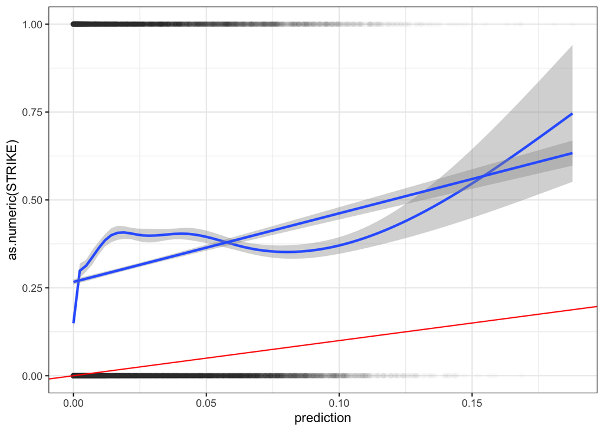

```r
# Model Predictions
sl_preds_strike <- sliders %>%
  mutate(prediction_log = predict(sl_model_strike, sliders),
         prediction = 1 / (1 + exp(-prediction_log)),
         rounded_pred = case_when(
           prediction >= 0.5 ~ 1,
           prediction < 0.5 ~ 0
         )) %>%
  filter(!is.na(prediction))

ggplot(sl_preds_barrel, aes(x = prediction, y = as.numeric(STRIKE))) +
  geom_point(alpha = 0.01) +
  geom_smooth() +
  geom_smooth(method = "lm") +
  geom_abline(slope = 1, intercept = 0, color = "red") +
  theme_bw()
```

#### STRIKE Fastball Initial Model

```r
# Initial Model
fb_model_strike_all <- glm(STRIKE ~ pitch_speed + pfx_x + pfx_z + plate_x + plate_z + zone +
              count + pfx_total + speed_change + break_change + distance + prev_pitch +
                release_spin_rate + I(plate_x^2) + I(plate_z^2) + pred_bwhiff,
              data = fastballs, family = binomial)

# Model Evaluation
summary(fb_model_strike_all)
```

```
##
## Call:
## glm(formula = STRIKE ~ pitch_speed + pfx_x + pfx_z + plate_x +
##     plate_z + zone + count + pfx_total + speed_change + break_change +
##     distance + prev_pitch + release_spin_rate + I(plate_x^2) +
##     I(plate_z^2) + pred_bwhiff, family = binomial, data = fastballs)
##
## Coefficients:
##                       Estimate Std. Error z value Pr(>|z|)
## (Intercept)          8.888e-01  7.246e+01   0.012 0.990214
## pitch_speed          2.194e-02  5.281e-03   4.155 3.26e-05 ***
## pfx_x                1.602e-01  5.678e-02   2.821 0.004788 **
## pfx_z               -3.053e-01  7.663e-02  -3.984 6.77e-05 ***
## plate_x              3.157e-01  2.851e-02  11.074  < 2e-16 ***
## plate_z              4.195e+00  1.791e-01  23.421  < 2e-16 ***
## zone1                4.956e-02  1.878e-01   0.264 0.791854
## zone2               -3.223e-02  1.097e-01  -0.294 0.768930
## zone3                9.468e-01  1.484e-01   6.382 1.75e-10 ***
## zone4                6.241e-02  6.333e-02   0.985 0.324445
## zone6                8.816e-01  5.228e-02  16.865  < 2e-16 ***
## zone7                1.223e+00  7.657e-02  15.969  < 2e-16 ***
## zone8                9.167e-01  6.535e-02  14.028  < 2e-16 ***
## zone9                1.717e+00  6.547e-02  26.219  < 2e-16 ***
## zone11               1.527e-01  2.158e-01   0.707 0.479348
## zone12               1.072e+00  1.317e-01   8.139 3.98e-16 ***
## zone13               7.699e-01  8.990e-02   8.563  < 2e-16 ***
## zone14               3.820e-01  7.537e-02   5.068 4.01e-07 ***
## zone16               4.928e-01  5.222e-02   9.437  < 2e-16 ***
## zone17              -2.841e-02  2.104e-01  -0.135 0.892613
## count0_1            -1.048e+01  7.246e+01  -0.145 0.884966
## count0_2            -1.093e+01  7.246e+01  -0.151 0.880119
## count1_0            -1.017e+01  7.246e+01  -0.140 0.888412
## count1_1            -1.062e+01  7.246e+01  -0.147 0.883464
## count1_2            -1.088e+01  7.246e+01  -0.150 0.880677
## count2_0            -1.025e+01  7.246e+01  -0.142 0.887467
## count2_1            -1.075e+01  7.246e+01  -0.148 0.882077
## count2_2            -1.107e+01  7.246e+01  -0.153 0.878627
## count3_0            -9.167e+00  7.246e+01  -0.127 0.899335
## count3_1            -1.077e+01  7.246e+01  -0.149 0.881839
## count3_2            -1.134e+01  7.246e+01  -0.157 0.875609
## pfx_total            3.700e-01  1.204e-01   3.073 0.002116 **
## speed_change         2.504e-02  1.398e-02   1.791 0.073287 .
## break_change         8.505e-01  1.116e-01   7.622 2.49e-14 ***
## distance            -3.223e-01  1.769e-01  -1.822 0.068453 .
## prev_pitchFastball   6.251e-02  3.135e-02   1.994 0.046144 *
## prev_pitchNone      -9.802e+00  7.246e+01  -0.135 0.892397
## prev_pitchOff Speed  7.260e-02  6.018e-02   1.206 0.227680
## release_spin_rate    2.843e-04  7.555e-05   3.763 0.000168 ***
## I(plate_x^2)        -1.020e+00  5.733e-02 -17.793  < 2e-16 ***
## I(plate_z^2)        -7.255e-01  2.545e-02 -28.508  < 2e-16 ***
## pred_bwhiff          5.183e+00  4.419e-01  11.728  < 2e-16 ***
## ---
## Signif. codes:  0 '***' 0.001 '**' 0.01 '*' 0.05 '.' 0.1 ' ' 1
##
## (Dispersion parameter for binomial family taken to be 1)
##
##     Null deviance: 52121  on 42647  degrees of freedom
## Residual deviance: 43710  on 42606  degrees of freedom
##   (129 observations deleted due to missingness)
## AIC: 43794
##
## Number of Fisher Scoring iterations: 8
```

#### STRIKE Fastball Refined Model & Predictions

Variables Removed: count, zone

```r
# Refined Model

fb_model_strike <- glm(STRIKE ~ pitch_speed + pfx_x + pfx_z + plate_x + plate_z +
              pfx_total + speed_change + break_change + distance + prev_pitch +
                release_spin_rate + I(plate_x^2) + I(plate_z^2) + pred_bwhiff,
              data = fastballs, family = binomial)

# Model Evaluation
summary(fb_model_strike)
```

```
##
## Call:
## glm(formula = STRIKE ~ pitch_speed + pfx_x + pfx_z + plate_x +
##     plate_z + pfx_total + speed_change + break_change + distance +
##     prev_pitch + release_spin_rate + I(plate_x^2) + I(plate_z^2) +
##     pred_bwhiff, family = binomial, data = fastballs)
##
## Coefficients:
##                       Estimate Std. Error z value Pr(>|z|)
## (Intercept)         -7.4020488  0.4944984 -14.969  < 2e-16 ***
## pitch_speed          0.0150404  0.0051101   2.943 0.003248 **
## pfx_x                0.1623110  0.0549666   2.953 0.003148 **
## pfx_z               -0.3214970  0.0742288  -4.331 1.48e-05 ***
## plate_x              0.4317013  0.0216633  19.928  < 2e-16 ***
## plate_z              4.0679869  0.1421078  28.626  < 2e-16 ***
## pfx_total            0.4019531  0.1167429   3.443 0.000575 ***
## speed_change        -0.0587447  0.0131476  -4.468 7.89e-06 ***
## break_change         0.9284322  0.1084656   8.560  < 2e-16 ***
## distance            -1.3178496  0.1531452  -8.605  < 2e-16 ***
## prev_pitchFastball   0.1059397  0.0301722   3.511 0.000446 ***
## prev_pitchNone       0.7716481  0.0317595  24.297  < 2e-16 ***
## prev_pitchOff Speed -0.0458910  0.0580773  -0.790 0.429428
## release_spin_rate    0.0002425  0.0000732   3.313 0.000923 ***
## I(plate_x^2)        -0.7840803  0.0511505 -15.329  < 2e-16 ***
## I(plate_z^2)        -0.5729397  0.0202317 -28.319  < 2e-16 ***
## pred_bwhiff          4.5379833  0.4289631  10.579  < 2e-16 ***
## ---
## Signif. codes:  0 '***' 0.001 '**' 0.01 '*' 0.05 '.' 0.1 ' ' 1
##
## (Dispersion parameter for binomial family taken to be 1)
##
##     Null deviance: 52121  on 42647  degrees of freedom
## Residual deviance: 45715  on 42631  degrees of freedom
##   (129 observations deleted due to missingness)
## AIC: 45749
##
## Number of Fisher Scoring iterations: 5
```

[figure not shown]

```r
# Model Predictions
fb_preds_strike <- fastballs %>%
  mutate(prediction_log = predict(fb_model_strike, fastballs),
         prediction = 1 / (1 + exp(-prediction_log)),
         rounded_pred = case_when(
           prediction >= 0.5 ~ 1,
           prediction < 0.5 ~ 0
         )) %>%
  filter(!is.na(prediction))

# fb_preds_strike %>%
#   mutate(prediction = round(prediction, 2)) %>%
#   group_by(prediction) %>%
#   summarize(n = n(), STRIKE_rate = mean(STRIKE)) %>%
#   as.data.frame() %>%
#   ggplot(aes(x = prediction, y = STRIKE_rate)) +
#   geom_point(aes(size = n)) + # size of bin shown on graph
#   coord_fixed() +
#   geom_smooth(se = FALSE) +
#   labs(y = "observed strike rate",
#        x = "projected strike rate",
#        title = "Fastball Strike Model Prediction",
#        subtitle = "Strike rate by predicted strike rate",
#        caption = "Strike rate have a 1% bin width")


ggplot(sl_preds_barrel, aes(x = prediction, y = as.numeric(STRIKE))) +
  geom_point(alpha = 0.01) +
  geom_smooth() +
  geom_smooth(method = "lm") +
  geom_abline(slope = 1, intercept = 0, color = "red") +
  theme_bw()
```